# Capital Study: Data Cleaning

Group 10

## Data Cleaning and Exclusion Criteria

- The final analysis will only concern itself with correct trials
- Excluding all left-handed participants
- Participants who make incorrect category judgements in all three practice trials will be discarded
- Data of participants who only have an accuracy of 50% will not be taken into account
- Exclude all data from participants who complete the experiment in under 500 ms or take longer than 60000 ms
- Trials which contain more than three flips along the y-axis will be taken out from the analysis
- Exclude trail with seaturtle - (because we messed that one up)

```r
#import data
xdata_raw <- read_delim("Results_Table_Main.csv",
    ";", escape_double = FALSE, trim_ws = TRUE)


as.tibble(xdata_raw)
```

```
## # A tibble: 2,561 x 33
##    submission_id    MI QUD      RT   age comments correct correctness education
##            <dbl> <dbl> <lgl> <dbl> <dbl> <chr>    <chr>   <chr>       <chr>
##  1          2141    NA NA     3179    24 <NA>     <NA>    <NA>        Graduate~
##  2          2141    NA NA     2318    24 <NA>     <NA>    <NA>        Graduate~
##  3          2141    10 NA     3157    24 <NA>     Mammal  Correct     Graduate~
##  4          2141   355 NA     2186    24 <NA>     Mammal  Correct     Graduate~
##  5          2141   659 NA     1214    24 <NA>     Mammal  Correct     Graduate~
##  6          2141   447 NA     1778    24 <NA>     Reptile Correct     Graduate~
##  7          2141   525 NA     1338    24 <NA>     Fish    Correct     Graduate~
##  8          2141   471 NA     1692    24 <NA>     Reptile Correct     Graduate~
##  9          2141   385 NA     1323    24 <NA>     Bird    Correct     Graduate~
## 10          2141   409 NA     1662    24 <NA>     Fish    Correct     Graduate~
## # ... with 2,551 more rows, and 24 more variables: endTime <dbl>,
## #   experiment_id <dbl>, gender <chr>, languages <chr>,
## #   mousetrackingDuration <dbl>, mousetrackingStartTime <dbl>,
## #   timestamps_get_response <chr>, xpos_get_response <chr>,
## #   ypos_get_response <chr>, movementDirection <dbl>, option1 <chr>,
## #   option2 <chr>, originX <dbl>, originY <dbl>, question <chr>,
## #   response <chr>, startDate <chr>, startTime <dbl>, startingTime <dbl>,
## #   timeSpent <dbl>, traveledDistance <dbl>, trial_name <chr>,
## #   trial_number <dbl>, typicality <chr>
```

```r
#filter out test trials and subjects from pilot study
xdata_new_capital <- xdata_raw %>%
  subset(submission_id != "1993" & submission_id != "1992" & submission_id != "1991" & submission_id != "1990" & submission_id != "1989" &
           submission_id != "1611" & submission_id != "1640" & submission_id != "1641"
         & submission_id != "1642" & submission_id != "1643" & submission_id != "1644")
```

# DATA EXCLUSION

```r
##1. Excluding all left-handed participants

#create handedness table to merge with actual data
#necessary in order to filter out left handed participants
xdata_handedness <- xdata_new_capital %>%
  select(submission_id, response, trial_name) %>%
  filter(trial_name == "mouse_question" | trial_name == "hand_question") %>%
  spread(trial_name, response)

xdata_handedness
```

```
## # A tibble: 57 x 3
##    submission_id hand_question mouse_question
##            <dbl> <chr>         <chr>
##  1          2062 Right         Mouse
##  2          2063 Right         Mouse
##  3          2065 Left          Touch
##  4          2066 Right         Touch
##  5          2067 Right         Mouse
##  6          2069 Right         Mouse
##  7          2076 Right         Touch
##  8          2078 Right         Mouse
##  9          2091 Right         Touch
## 10          2092 Left          Mouse
## # ... with 47 more rows
```

```r
##2. Participants who make incorrect category judgements in all three practice trials will be discarded

#creating table to discard subjects who failed all 3 training trials
xdata_training_correct <- xdata_new_capital %>%
  select(submission_id, correctness, trial_name) %>%
    group_by(correctness, submission_id) %>%
  filter(trial_name == "training") %>%
  #count the amount of incorrect trials
  count(failed = correctness == "Incorrect") %>%
  #showing all subjects who failed all training trials
  subset(failed == "TRUE" & n != 3)

#there are no participants that failed all training trials
xdata_training_correct
```

```
## # A tibble: 14 x 4
## # Groups:   correctness, submission_id [14]
##    correctness submission_id failed     n
##    <chr>               <dbl> <lgl>  <int>
##  1 Incorrect            2076 TRUE       1
##  2 Incorrect            2095 TRUE       1
##  3 Incorrect            2097 TRUE       1
##  4 Incorrect            2100 TRUE       1
##  5 Incorrect            2101 TRUE       1
##  6 Incorrect            2108 TRUE       1
##  7 Incorrect            2109 TRUE       1
##  8 Incorrect            2114 TRUE       2
##  9 Incorrect            2121 TRUE       1
## 10 Incorrect            2122 TRUE       1
## 11 Incorrect            2129 TRUE       1
## 12 Incorrect            2131 TRUE       1
## 13 Incorrect            2137 TRUE       1
## 14 Incorrect            2139 TRUE       1
```

```r
#taking only the relevant participants for the pilot study
#excluding left-handed participants
#only taking main trials
xdata_main <- xdata_new_capital %>%
  #we only take the data from the capital study
  filter(correct == "Capital" | correct == "Non-Capital") %>%
  #merge xdata with xdata_handedness
  full_join(xdata_handedness) %>%
  #take all right handed participants
  filter(hand_question == "Right")


xdata_main
```

```
## # A tibble: 742 x 35
##    submission_id    MI QUD      RT   age comments correct correctness education
##            <dbl> <dbl> <lgl> <dbl> <dbl> <chr>    <chr>   <chr>       <chr>
##  1          2141   361 NA     1048    24 <NA>     Capital Correct     Graduate~
##  2          2141   305 NA     1364    24 <NA>     Capital Correct     Graduate~
##  3          2141   173 NA     1518    24 <NA>     Capital Correct     Graduate~
##  4          2141   518 NA     1706    24 <NA>     Non-Ca~ Correct     Graduate~
##  5          2141   394 NA     1042    24 <NA>     Capital Correct     Graduate~
##  6          2141   432 NA     1362    24 <NA>     Non-Ca~ Correct     Graduate~
##  7          2141    18 NA      919    24 <NA>     Capital Correct     Graduate~
##  8          2141   236 NA     1244    24 <NA>     Capital Correct     Graduate~
##  9          2141   269 NA     1590    24 <NA>     Non-Ca~ Correct     Graduate~
## 10          2141   142 NA     1573    24 <NA>     Non-Ca~ Correct     Graduate~
## # ... with 732 more rows, and 26 more variables: endTime <dbl>,
## #   experiment_id <dbl>, gender <chr>, languages <chr>,
## #   mousetrackingDuration <dbl>, mousetrackingStartTime <dbl>,
## #   timestamps_get_response <chr>, xpos_get_response <chr>,
## #   ypos_get_response <chr>, movementDirection <dbl>, option1 <chr>,
## #   option2 <chr>, originX <dbl>, originY <dbl>, question <chr>,
## #   response <chr>, startDate <chr>, startTime <dbl>, startingTime <dbl>,
## #   timeSpent <dbl>, traveledDistance <dbl>, trial_name <chr>,
## #   trial_number <dbl>, typicality <chr>, hand_question <chr>,
## #   mouse_question <chr>
```

```r
##3. Data of participants who only have an accuracy of 50% will not be taken into account


#creating table to discard subjects who failed 50% of the answers
xdata_wrong <- xdata_new_capital %>%
  #take submission_id to see which subject failed 50% of the answers
  group_by(submission_id) %>%
  #count all incorrect main trials per subject
  count(failed = correctness == "Incorrect") %>%
  #take all subject with 50% wrong trials
  subset(failed == "TRUE" & n >=10)

#there are no participants that got 50% of the answers wrong
xdata_wrong
```

```
## # A tibble: 1 x 3
## # Groups:   submission_id [1]
##   submission_id failed     n
##           <dbl> <lgl>  <int>
## 1          2129 TRUE      10
```

```r
##4. Exclude all data from participants who complete the experiment in under 500 ms or take longer than 6000 ms
##5.The final analysis will only concern itself with correct trial

xdata_capital <- xdata_main %>%
  #only taking correct trials into account
  filter(correctness == "Correct") %>%
  # taking out subjects who are faster than 500 ms and slower than 1 min
  subset(RT >= 500 & RT <= 60000 & submission_id != "2129") %>%
  #taking out for analysis non-relevant variables
  select(-c(QUD, age, comments, education, MI, gender, languages, experiment_id,option1, option2, response,
            trial_name, trial_number, hand_question, mouse_question))

xdata_capital
```

```
## # A tibble: 588 x 20
##    submission_id    RT correct correctness endTime mousetrackingDu~
##            <dbl> <dbl> <chr>   <chr>         <dbl>            <dbl>
##  1          2141  1048 Capital Correct     1.60e12              901
##  2          2141  1364 Capital Correct     1.60e12             1204
##  3          2141  1518 Capital Correct     1.60e12             1405
##  4          2141  1706 Non-Ca~ Correct     1.60e12             1591
##  5          2141  1042 Capital Correct     1.60e12              856
##  6          2141  1362 Non-Ca~ Correct     1.60e12             1336
##  7          2141   919 Capital Correct     1.60e12              784
##  8          2141  1244 Capital Correct     1.60e12             1183
##  9          2141  1590 Non-Ca~ Correct     1.60e12             1590
## 10          2141  1573 Non-Ca~ Correct     1.60e12             1351
## # ... with 578 more rows, and 14 more variables: mousetrackingStartTime <dbl>,
## #   timestamps_get_response <chr>, xpos_get_response <chr>,
## #   ypos_get_response <chr>, movementDirection <dbl>, originX <dbl>,
## #   originY <dbl>, question <chr>, startDate <chr>, startTime <dbl>,
## #   startingTime <dbl>, timeSpent <dbl>, traveledDistance <dbl>,
## #   typicality <chr>
```

- No subjects had all training trials wrong
- Subject 2129 had 10 incorrect answers - taking out subject 2129

# TRAJECTORY PREPROCESSING

```r
#tibble into data frame for mousetrap object
head(as.data.frame(xdata_capital))
```

[output not shown]

[output cut: 41 more lines]

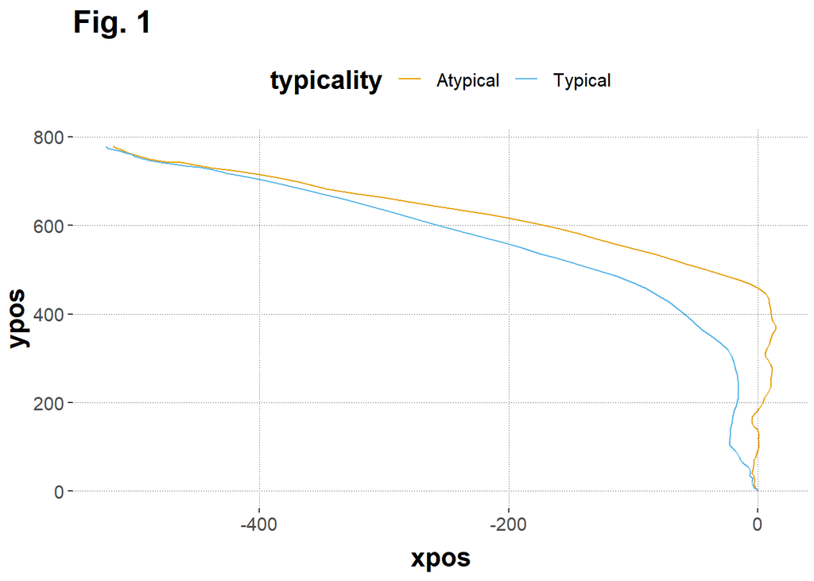

```r
#creating mousetrap object for further anaylsis
mt_data_capital <- mt_import_mousetrap(xdata_capital)

#all trajectories are remapped to the left
mt_data_capital <- mt_remap_symmetric(mt_data_capital)

#setting the starting point of the trajectories equally
mt_data_capital <- mt_align_start(mt_data_capital, start=c(0,0))

mt_data_capital <- mt_derivatives(mt_data_capital)
#important for later creating MAD and AUC values
mt_data_capital <- mt_measures(mt_data_capital)

#time-normalizing trajectories
mt_data_capital <- mt_time_normalize(mt_data_capital)


#plot aggregated time-normalized trajectories
mt_plot_aggregate(mt_data_capital, use="tn_trajectories", x="xpos", y="ypos", color="typicality",
subject_id="submission_id")+
    ggtitle("Fig. 1")
```

Fig. 1: Display of over all trials avaraged trajactory for each trial type. All trajectories have been flipped to the left. Starting and end point was set equall over all trajectories of each trail type.

# AGGREGATE TRAJECTORY CURVATURE

```r
#aggregating maximum absolut deviation (MAD) values for analysis
agg_mad_capital <- mt_aggregate_per_subject(mt_data_capital,
use_variables="MAD", use2_variables="typicality",
subject_id="submission_id")

agg_auc_capital <- mt_aggregate_per_subject(mt_data_capital,
use_variables="AUC", use2_variables="typicality",
subject_id="submission_id")
```

# CLUSTER AGGREGATION & PROTOTYPE CLASSIFICATION

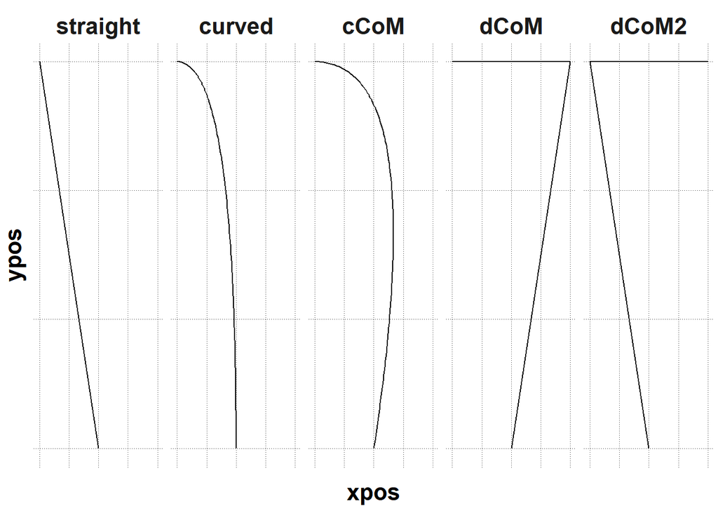

```r
#Spatialize trajectories
mt_data_capital <- mt_spatialize(mt_data_capital)

#Cluster trajectories
mt_data_capital <- mt_cluster(mt_data_capital, use = "sp_trajectories")

mt_plot(mt_prototypes,facet_col="mt_id",only_ggplot = TRUE)+
  geom_path()+
  facet_grid(cols = vars(factor(mt_id,levels=rownames(mt_prototypes))))+
  theme(axis.text=ggplot2::element_blank(),axis.ticks=ggplot2::element_blank())
```

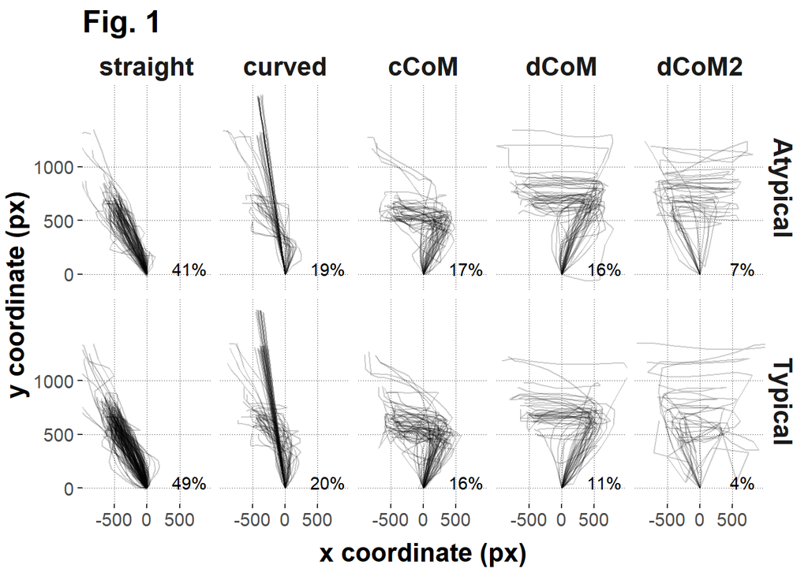

```r
mt_data_capital <- mt_map(mt_data_capital,prototypes = mt_prototypes,
  save_as = "measures", grouping_variables = "typicality")
mt_data_capital$data$prototype_label <- mt_data_capital$measures$prototype_label

prototype_percentages <- mt_data_capital$data %>%
  group_by(typicality,prototype_label) %>%
  summarise(n=n()) %>%
  mutate(Percent=paste(round(100*n/sum(n)),"%",sep=""))

mt_plot(mt_data_capital, use = "sp_trajectories",
  x = "xpos", y = "ypos", facet_col = "prototype_label", facet_row="typicality",alpha=.2)+
  xlab("x coordinate (px)") + ylab("y coordinate (px)")+
  geom_text(data=prototype_percentages,aes(label=Percent),x=650,y=50)+
  scale_y_continuous(breaks=c(0,500,1000))+
  coord_cartesian(xlim=c(-900,900))+
    ggtitle("Fig. 1")
```

Fig. 1: The plot shows the percentages of trajectories for each trial type, which are assigned to the respective trajectory prototypes.

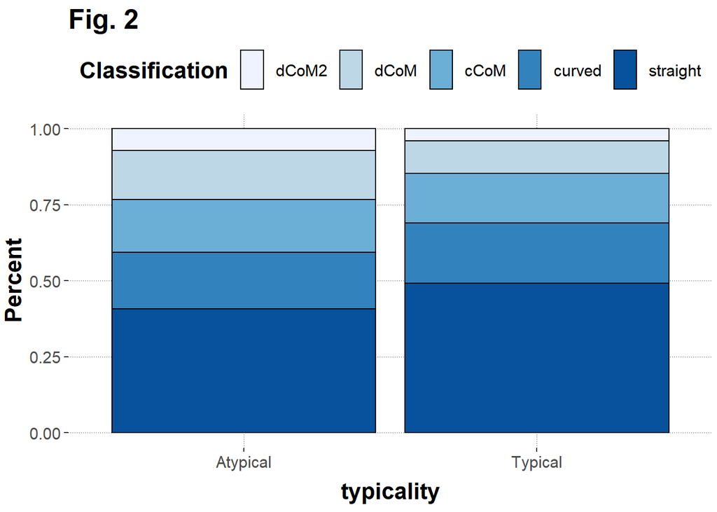

```r
rel_freq_agg <- mt_data_capital$data %>%
  group_by(typicality,prototype_label) %>%
  summarise(n=n()) %>%
  mutate(Percent=n/sum(n))

ggplot(rel_freq_agg,aes(x=typicality,y=Percent,fill=forcats::fct_rev(prototype_label)))+
  geom_bar(stat="identity",color="black")+
  scale_fill_brewer(type="seq",name="Classification")+
  facet_grid()+
    ggtitle("Fig. 2")
```

Fig.2: The graph illustrates the proportion of trajectory prototypes for each trial type. The proportion is given in percent.

# Bimodality check

```r
# Standardize AUC per participant
mt_data_capital <- mt_standardize(mt_data_capital, use_variables = "AUC", within = "submission_id")

# Calculate bimodality coefficient
 mt_check_bimodality(mt_data_capital, use_variables = "z_AUC",
   grouping_variables = "typicality", methods = "BC")
```

```
## $BC
##   typicality     z_AUC
## 1   Atypical 0.5006168
## 2    Typical 0.5555211
```

```r
# Standardize MAD per participant
mt_data_capital <- mt_standardize(mt_data_capital, use_variables = "MAD", within = "submission_id")

# Calculate bimodality coefficient
 mt_check_bimodality(mt_data_capital, use_variables = "z_MAD",
   grouping_variables = "typicality", methods = "BC")
```

```
## $BC
##   typicality     z_MAD
## 1   Atypical 0.4715620
## 2    Typical 0.5290145
```

```r
# Standardize MAD per participant
mt_data_capital <- mt_standardize(mt_data_capital, use_variables = "RT", within = "submission_id")

# Calculate bimodality coefficient
 mt_check_bimodality(mt_data_capital, use_variables = "z_RT",
   grouping_variables = "typicality", methods = "BC")
```

```
## $BC
##   typicality      z_RT
## 1   Atypical 0.4984364
## 2    Typical 0.5694746
```

```r
 # Standardize MAD per participant
mt_data_capital <- mt_standardize(mt_data_capital, use_variables = "initiation_time", within = "submission_id")

# Calculate bimodality coefficient
 mt_check_bimodality(mt_data_capital, use_variables = "z_initiation_time",
   grouping_variables = "typicality", methods = "BC")
```

```
## $BC
##   typicality z_initiation_time
## 1   Atypical         0.4434028
## 2    Typical         0.4381015
```

```
## spatializing trajectories
## calculate image
## smooth image
## enhance image by 72.1
```

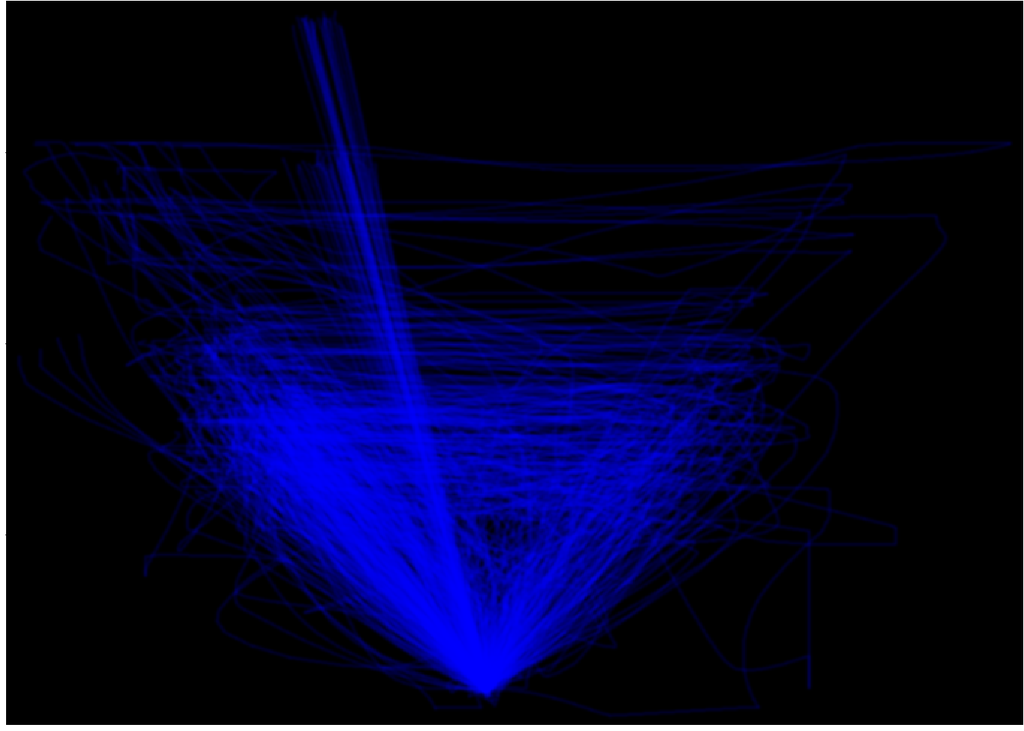

```r
#plot trajectories
mt_heatmap_ggplot(mt_data_capital)
```

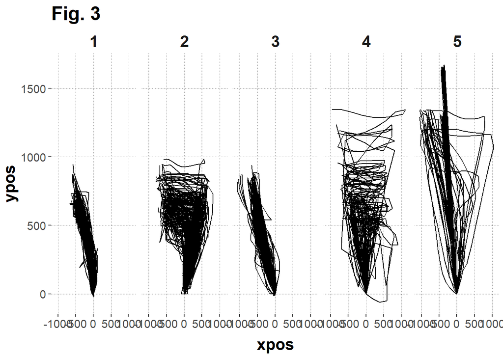

```r
#plot clustered trajectories
mt_plot(mt_data_capital,use="sp_trajectories",
  use2="clustering",facet_col="cluster")+
    ggtitle("Fig. 3")
```

Fig.3: The graph displays the given trajectories from the data for each cluster type.

```r
#store mousetrap object in results
results <- merge(mt_data_capital$data, mt_data_capital$measures, by="mt_id")

#export results in long format for further analysis
agg_xdata_capital <- mt_export_long(results)

#as tibble for easier handling
head(as.tibble(agg_xdata_capital))
```

```
## # A tibble: 6 x 54
##   mt_id submission_id  RT.x correct correctness endTime mousetrackingDu~
##   <chr>         <dbl> <dbl> <chr>   <chr>         <dbl>            <dbl>
## 1 1              2141  1048 Capital Correct     1.60e12              901
## 2 2              2141  1364 Capital Correct     1.60e12             1204
## 3 3              2141  1518 Capital Correct     1.60e12             1405
## 4 4              2141  1706 Non-Ca~ Correct     1.60e12             1591
## 5 5              2141  1042 Capital Correct     1.60e12              856
## 6 6              2141  1362 Non-Ca~ Correct     1.60e12             1336
## # ... with 47 more variables: mousetrackingStartTime <dbl>,
## #   movementDirection <dbl>, originX <dbl>, originY <dbl>, question <chr>,
## #   startDate <chr>, startTime <dbl>, startingTime <dbl>, timeSpent <dbl>,
## #   traveledDistance <dbl>, typicality <chr>, prototype_label.x <fct>,
## #   xpos_max <dbl>, xpos_min <dbl>, ypos_max <dbl>, ypos_min <dbl>, MAD <dbl>,
## #   MAD_time <dbl>, MD_above <dbl>, MD_above_time <dbl>, MD_below <dbl>,
## #   MD_below_time <dbl>, AD <dbl>, AUC <dbl>, xpos_flips <dbl>,
## #   ypos_flips <dbl>, xpos_reversals <dbl>, ypos_reversals <dbl>, RT.y <dbl>,
## #   initiation_time <dbl>, idle_time <dbl>, total_dist <dbl>, vel_max <dbl>,
## #   vel_max_time <dbl>, vel_min <dbl>, vel_min_time <dbl>, acc_max <dbl>,
## #   acc_max_time <dbl>, acc_min <dbl>, acc_min_time <dbl>, min_dist <dbl>,
## #   prototype <int>, prototype_label.y <fct>, z_AUC <dbl>, z_MAD <dbl>,
## #   z_RT <dbl>, z_initiation_time <dbl>
```

```r
##6. Trials which contain more than three flips along the y-axis will be taken out from the analysis

#creating final data table for bayesian inference
capital <- agg_xdata_capital %>%
    select(-c(endTime, mousetrackingStartTime, startDate, startTime, startingTime, timeSpent, xpos_max, xpos_min, xpos_reversals, ypos_max, ypos_min, MAD_time,MD_above, MD_above_time, RT.y, idle_time, vel_max, vel_max_time, vel_min, vel_min_time, acc_max, acc_max_time, min_dist, prototype, z_MAD, MD_below, MD_below_time, AD, ypos_reversals, acc_min, acc_min_time, originX, originY, prototype_label.x, correct)) %>%
  #taking out all trials which have 3 or more flips along the x and y-axis
  subset(xpos_flips <= 3 & ypos_flips <= 3) %>%
  rename(RT = RT.x, unique_trial_id = mt_id, trial_type = typicality, prototype_label = prototype_label.y, subject_id = submission_id,
         exemplar = question)


capital
```

```
##     unique_trial_id subject_id    RT correctness mousetrackingDuration
## 1                 1       2141  1048     Correct                   901
## 2                 2       2141  1364     Correct                  1204
## 3                 3       2141  1518     Correct                  1405
## 4                 4       2141  1706     Correct                  1591
## 5                 5       2141  1042     Correct                   856
## 6                 6       2141  1362     Correct                  1336
## 7                 7       2141   919     Correct                   784
## 10               10       2141  1573     Correct                  1351
## 12               12       2141  1316     Correct                  1173
## 13               13       2141  1451     Correct                  1317
## 14               14       2141  1340     Correct                  1117
## 15               15       2140  1810     Correct                  1477
## 16               16       2140  6025     Correct                  5413
## 17               17       2140  2668     Correct                  1878
```

[output cut: 1841 more lines]

```r
write.csv(capital, "~/CS-SS20/Experimental_Psychology_Lab/Final_Project/XPLab2020_FinalProject/main/Capital Study/capital_data.csv", row.names = FALSE)
```